# Markov chain Monte Carlo

Fernando Miguez

8/3/2020

# Markov chain Monte Carlo

https://en.wikipedia.org/wiki/Markov_chain_Monte_Carlo

> A Markov chain is a stochastic model describing a sequence of possible events in which the probability of each event depends only on the state attained in the previous event

## Simple Metropolis

Let’s sketch a simple example of a Metropolis algorithm for a single parameter

First step, we choose a starting point for our parameter, generate *noise* from a random normal and add it to our parameter

$$\theta_0 \\
\epsilon \sim N(0,1) \\
\theta_1 = \theta_0 + \epsilon$$
Now compute the Metropolis ratio, $f$ is a function which should be proportional to the likelihood and $x$ is the data. Note, this method could be used to calculate a simple mean even.

$$R = \frac{f(x | \theta_1)}{f(x | \theta_0)}$$

Note that when $R > 1$ it means that, according to our function $f$, $\theta_1$ is more plausible under our assumptions than $\theta_0$. This would mean that, at least, $\theta_1$ is a better guess than $\theta_0$. We don’t want to only accept better values of $\theta$ every single time. So what we do is generate a uniform random number $[0,1]$ and accept the new $\theta$ if $R$ is greater than that random number. This means that sometimes we will accept some new values for $\theta$ which are actually worse. This is needed so that we don’t get stuck at the maximum posterior density.

$$U \sim \text{Unif}(0,1) \\
\text{if} \; R \geq U \; \text{accept} \\
\text{otherwise} \; \text{reject}$$

```r
## I fix sigma to simplify the probelm and make it about
## estimating a single parameter
metrop <- function(x, n = 1e2, start = 1, sigma = 1){

  theta.old <- start

  theta.vec <- numeric(n)

  for(i in 1:n){

    theta.new <- theta.old + rnorm(1)

    f.0 <- sum(dnorm(x, mean = theta.old, sd = sigma, log = TRUE))
    f.1 <- sum(dnorm(x, mean = theta.new, sd = sigma, log = TRUE))

    U <- runif(1)

    ## As stated above f.0 is the log-likelihood, thus exp(f.0) would be the
    ## likelihood. If I take the log of R then
    ## log(R) = log(exp(f.1)) - log(exp(f.0))
    ## This simplifies to f.1 - f.0
    R <- f.1 - f.0

    if(R > log(U)){
      theta.old <- theta.new
    }

    theta.vec[i] <- theta.old
  }
  return(list(theta = theta.vec))
}

set.seed(1234)
y <- rnorm(20, 15, 3)

## The mean is easy
mean(y)
```

```
## [1] 14.24801
```

```r
## Confidence interval
confint(lm(y ~ 1))
```

```
##                2.5 %   97.5 %
## (Intercept) 12.82458 15.67144
```

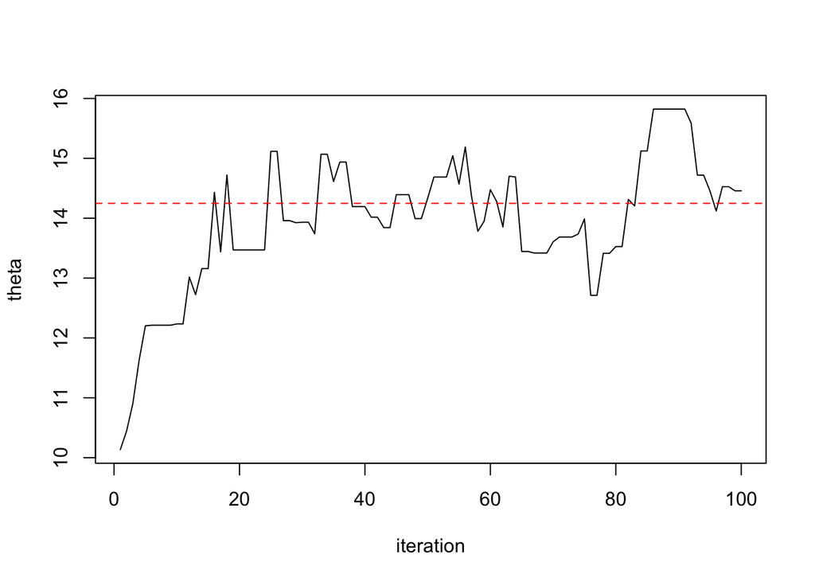

```r
## Using Metropolis
mm <- metrop(y, n = 100, start = 10, sigma = sd(y))

## Plotting the trace
plot(mm$theta, xlab = "iteration", ylab = "theta", type = "l")
abline(h = mean(y), col = "red", lty = 2)
```

```r
## Getting the distribution
mm2 <- metrop(y, n = 5e3, start = 7, sigma = sd(y))
## Computing the mean
mean(mm2$theta[500:5e3])
```

```
## [1] 14.20837
```

```r
## Confidence interval
quantile(mm2$theta[500:5e3], probs = c(0.025, 0.975))
```

```
##     2.5%    97.5%
## 12.89965 15.54239
```

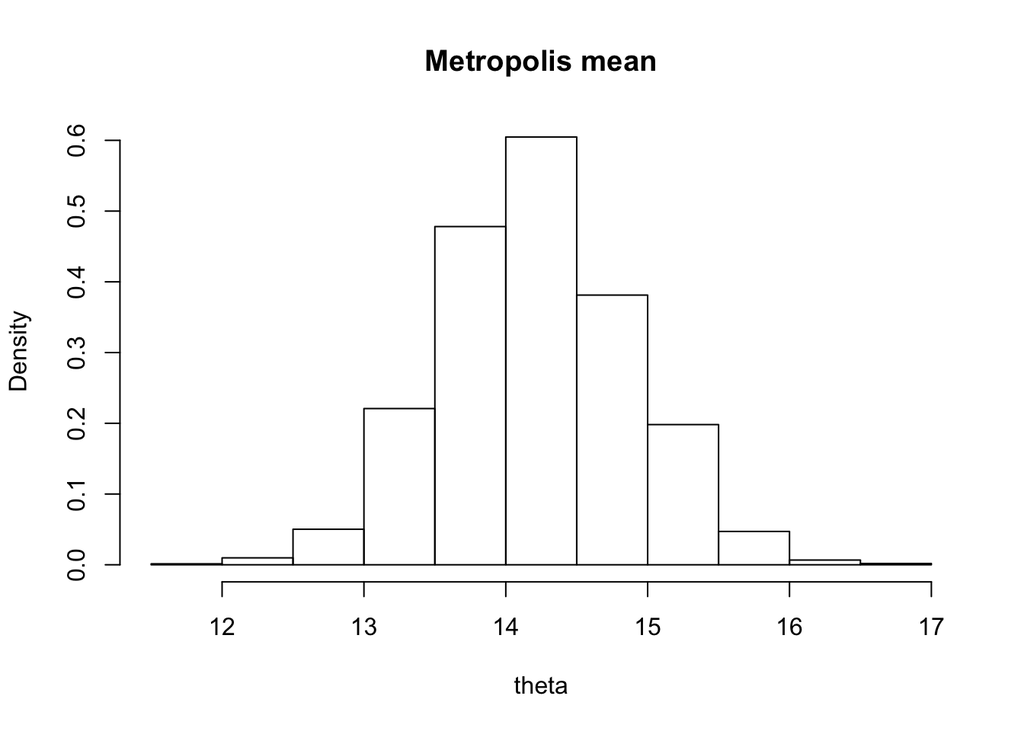

```r
## Distribution
hist(mm2$theta[500:5e3], xlab = "theta", main = "Metropolis mean", freq = FALSE)
```

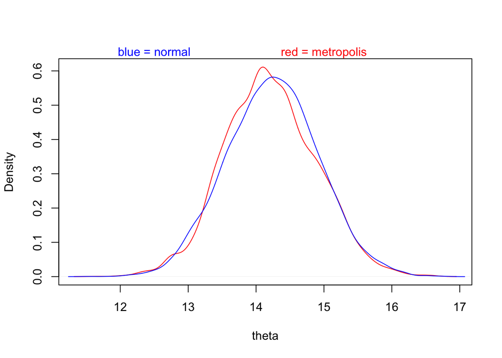

```r
## Comparing densities
ry <- rnorm(1e4, mean = mean(y), sd = sd(y)/sqrt(length(y)))
plot(density(mm2$theta[500:5e3]), main = "", xlab = "theta", col = "red")
lines(density(ry), col = "blue")
mtext("blue = normal", col = "blue", at = c(12.5, 1))
mtext("red = metropolis", col = "red", at = c(15, 1))
```

## Practice problems

### 9M1

I don’t expect that a uniform prior for sigma will have much of an effect on the estimates for model m9.1. The current value of sigma is 0.11, so well within the [0-1] range of the uniform prior.

```r
data(rugged)
d <- rugged
d$log_gdp <- log(d$rgdppc_2000)
dd <- d[ complete.cases(d$rgdppc_2000) , ]
dd$log_gdp_std <- dd$log_gdp / mean(dd$log_gdp)
dd$rugged_std <- dd$rugged / max(dd$rugged)
dd$cid <- ifelse( dd$cont_africa==1 , 1 , 2 )

## Using quadp
m8.3 <- quap(
    alist(
        log_gdp_std ~ dnorm( mu , sigma ) ,
        mu <- a[cid] + b[cid]*( rugged_std - 0.215 ) ,
        a[cid] ~ dnorm( 1 , 0.1 ) ,
        b[cid] ~ dnorm( 0 , 0.3 ) ,
        sigma ~ dexp( 1 )
    ) , data=dd )
precis( m8.3 , depth=2 )
```

```
##             mean          sd        5.5%       94.5%
## a[1]   0.8865738 0.015675402  0.86152151  0.91162615
## a[2]   1.0505448 0.009936424  1.03466444  1.06642509
## b[1]   0.1329508 0.074202653  0.01436067  0.25154101
## b[2]  -0.1424510 0.054748460 -0.22994958 -0.05495236
## sigma  0.1094919 0.005934996  0.10000663  0.11897716
```

```r
## R code 9.13
dat_slim <- list(
    log_gdp_std = dd$log_gdp_std,
    rugged_std = dd$rugged_std,
    cid = as.integer( dd$cid )
)
str(dat_slim)
```

```
## List of 3
##  $ log_gdp_std: num [1:170] 0.88 0.965 1.166 1.104 0.915 ...
##  $ rugged_std : num [1:170] 0.138 0.553 0.124 0.125 0.433 ...
##  $ cid        : int [1:170] 1 2 2 2 2 2 2 2 2 1 ...
```

```r
## R code 9.14
m9.1 <- ulam(
    alist(
        log_gdp_std ~ dnorm( mu , sigma ) ,
        mu <- a[cid] + b[cid]*( rugged_std - 0.215 ) ,
        a[cid] ~ dnorm( 1 , 0.1 ) ,
        b[cid] ~ dnorm( 0 , 0.3 ) ,
        sigma ~ dexp( 1 )
    ) , data=dat_slim , chains=1 )
m9.1p <- ulam(
    alist(
        log_gdp_std ~ dnorm( mu , sigma ) ,
        mu <- a[cid] + b[cid]*( rugged_std - 0.215 ) ,
        a[cid] ~ dnorm( 1 , 0.1 ) ,
        b[cid] ~ dnorm( 0 , 0.3 ) ,
        sigma ~ dunif( 0, 1 )
    ) , data=dat_slim , chains=1 )
```

### 9M2

Note: I don’t like that the rethinking package has a graphics side effect.

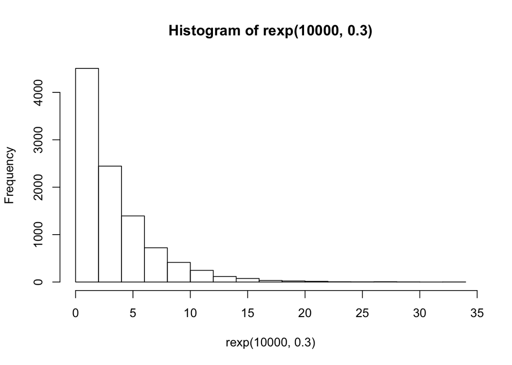

```r
## What does a dexp(0.3) mean?
par(mfrow = c(1,1))
hist(rexp(1e4, 0.3))
```

```r
## This forces the parameter to be positive
## which would not be a good choice for the slope
## Currently b[1] is positive and b[2] is negative so
## dexp(0.3) will force both slopes to be positive

m9.1a <- ulam(
    alist(
        log_gdp_std ~ dnorm( mu , sigma ) ,
        mu <- a[cid] + b[cid]*( rugged_std - 0.215 ) ,
        a[cid] ~ dnorm( 1 , 0.1 ) ,
        b[cid] ~ dexp( 0.3 ) ,
        sigma ~ dexp( 1 )
    ) , data=dat_slim , chains=1 )
## compare models
precis( m9.1 , depth = 2 )
```

```
##             mean          sd        5.5%       94.5%    n_eff     Rhat4
## a[1]   0.8865149 0.015275178  0.86084081  0.90866871 611.5765 0.9984042
## a[2]   1.0505900 0.010264200  1.03482117  1.06597502 691.6585 0.9979992
## b[1]   0.1389626 0.070722160  0.03681885  0.25233225 651.8119 0.9980415
## b[2]  -0.1414339 0.059938558 -0.23940790 -0.04601613 499.4892 1.0194444
## sigma  0.1115303 0.006397144  0.10157910  0.12185140 537.2352 0.9984934
```

```r
precis( m9.1a , depth = 2 )
```

```
##             mean          sd        5.5%      94.5%    n_eff     Rhat4
## a[1]  0.88658991 0.016059550 0.860371891 0.91275963 416.4846 0.9981002
## a[2]  1.04813897 0.010423627 1.031504601 1.06547433 528.9119 0.9985148
## b[1]  0.14463216 0.071185971 0.037535169 0.26942977 172.5792 0.9980374
## b[2]  0.01934244 0.017487566 0.001708247 0.05607964 474.6192 1.0107338
## sigma 0.11372443 0.006479722 0.104011570 0.12518186 373.8889 1.0006149
```

The new prior which forces the slope to be positive, has pushed teh b[2] to a value of 0.02 with an interval of (0 - 0.05) and, also, as a result b[1] to a value of 0.15. Only the positive values for the slope, given by the prior, are compatible with the model now.

### 9M3

How much warmup is enough? Or what is the minimum amount of warmup needed?

As he says in the chapter, it depends on what you are after. If you only want the ‘map’.

```r
m9.1w <- ulam(
    alist(
        log_gdp_std ~ dnorm( mu , sigma ) ,
        mu <- a[cid] + b[cid]*( rugged_std - 0.215 ) ,
        a[cid] ~ dnorm( 1 , 0.1 ) ,
        b[cid] ~ dexp( 0.3 ) ,
        sigma ~ dexp( 1 )
    ) , data=dat_slim , chains=1 , iter = 600)
```

```
## recompiling to avoid crashing R session
```

```r
## 500 iterations are not enough
```

I stopped getting complains after 600 iterations.

### 9H1

I’m not sure that in the model below the “y = 1” matters because there is no deterministic model that matches “y” to anything else. A Cauchy distribution has fat tails compared to a Normal. https://en.wikipedia.org/wiki/Cauchy_distribution. The moments are not defined, but it does have a mode and median, which are equal to zero in the example below. The distributions created by the posterior should be equivalent to randomly sampling from them.

```r
mp <- ulam(
  alist(
    a ~ dnorm(0, 1),
    b ~ dcauchy(0, 1)
  ), data = list(y = 1), chains = 1
)
```

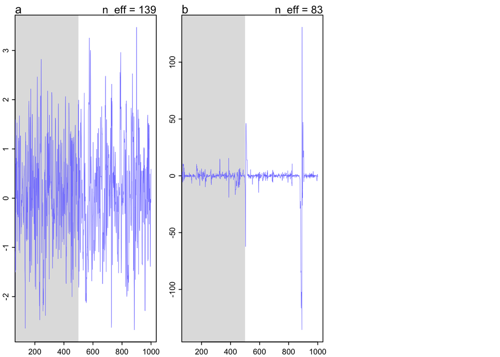

```r
par(mfrow = c(2,1))
traceplot(mp)
par(mfrow = c(1,1))
```

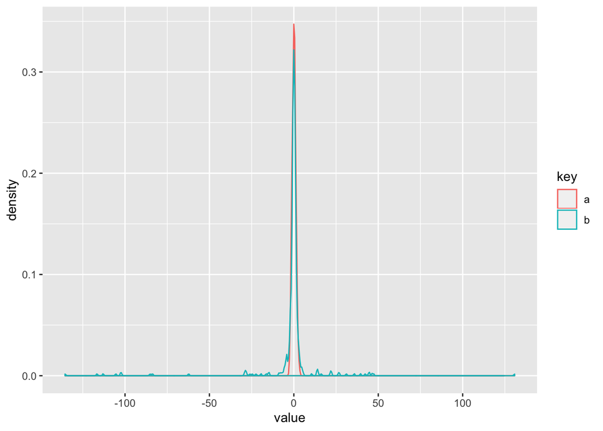

```r
mps <- extract.samples(mp)
mpsd <- gather(as.data.frame(mps))

ggplot(mpsd, aes(x = value, color = key)) +
  geom_density()
```

### 9H2

# How to set up models

I thought I would try to show how to set up models using other functions and this inevitably led me to reviewing a basic concept considered in earlier chapters.

## frequentist: lm

The GDP-ruggedness example can be easily set up with **lm**.

```r
dd$rugged_std2 <- dd$rugged_std - 0.215
dd$cid_f <- as.factor(dd$cid)

m8.3.lm <- lm(log_gdp_std ~ cid_f * rugged_std2, data = dd)

## This is equivalent to
## m8.3.lm <- lm(log_gdp_std ~ cid_f + rugged_std2 + cid_f:rugged_std2, data = dd)

m8.3.lm
```

```
##
## Call:
## lm(formula = log_gdp_std ~ cid_f * rugged_std2, data = dd)
##
## Coefficients:
##        (Intercept)              cid_f2         rugged_std2
##             0.8840              0.1671              0.1387
## cid_f2:rugged_std2
##            -0.2865
```

However, this model is not equivalent to the model SR wants us to fit. Here **(Intercept)** is the intercept for the regression for Africa and **cid_f2** is the difference between Africa and non-Africa. If we want non-Africa we need to do 1.0511. Similarly, the slope for Africa is **0.1387** and for non-Africa -0.1478.

Looking at the model matrix might help

```r
round(head(model.matrix(m8.3.lm)), 2)
```

```
##    (Intercept) cid_f2 rugged_std2 cid_f2:rugged_std2
## 3            1      0       -0.08               0.00
## 5            1      1        0.34               0.34
## 8            1      1       -0.09              -0.09
## 9            1      1       -0.09              -0.09
## 10           1      1        0.22               0.22
## 12           1      1       -0.21              -0.21
```

If we want to set up the model with **lm** the way SR likes it we need.

```r
m8.3.lm2 <- lm(log_gdp_std ~ cid_f + rugged_std2:cid_f - 1, data = dd)
```

Now, **cid_f1** is the intercept for Africa, **cid_f2** is the intercept for non-Africa. **cid_f1:rugged_std2** is the slope for Africa and **cid_f2:rugged_std2** is the slope for non-Africa. In the book, **cid_f1** equates to **a[1]** and **cid_f2** to **a[2]**. Similarly, **cid_f1:rugged_std2** equates to **b[1]** and **cif_f2:rugged_std2** to **b[2]**. We can get confidence intervals in the following way.

```r
round( confint(m8.3.lm2), 2)
```

```
##                    2.5 % 97.5 %
## cid_f1              0.85   0.92
## cid_f2              1.03   1.07
## cid_f1:rugged_std2 -0.01   0.29
## cid_f2:rugged_std2 -0.26  -0.04
```

The model matrix is now

```r
round(head(model.matrix(m8.3.lm2)), 2)
```

```
##    cid_f1 cid_f2 cid_f1:rugged_std2 cid_f2:rugged_std2
## 3       1      0              -0.08               0.00
## 5       0      1               0.00               0.34
## 8       0      1               0.00              -0.09
## 9       0      1               0.00              -0.09
## 10      0      1               0.00               0.22
## 12      0      1               0.00              -0.21
```

## Bayesian: brms

When trying to fit the same model with *brms* things are a little bit different.

```r
## Easy brms. This model is the Bayesian version of the model m8.3.lm above
## But again this is not the same as in the book
m8.3.brms1 <- brm(log_gdp_std ~ cid_f + rugged_std2 + cid_f:rugged_std2,
                  data = dd)
## Also, it does not have explicit priors for the model parameters
## What is brms doing under the hood?
prior_summary(m8.3.brms1)
```

```
##                  prior     class               coef group resp dpar nlpar
## 1                              b
## 2                              b             cid_f2
## 3                              b cid_f2:rugged_std2
## 4                              b        rugged_std2
## 5 student_t(3, 1, 2.5) Intercept
## 6 student_t(3, 0, 2.5)     sigma
##   bound
## 1
## 2
## 3
## 4
## 5
## 6
```

```r
## This is what we need to do to generate a model equivalent to
## m8.3.lm2 above
m8.3.brms2 <- brm(log_gdp_std ~ 0 + cid_f + cid_f:rugged_std2,
                 data = dd)
## Still does not have explicit priors
prior_summary(m8.3.brms2)
```

```
##                  prior class               coef group resp dpar nlpar
## 1                          b
## 2                          b             cid_f1
## 3                          b cid_f1:rugged_std2
## 4                          b             cid_f2
## 5                          b cid_f2:rugged_std2
## 6 student_t(3, 0, 2.5) sigma
##   bound
## 1
## 2
## 3
## 4
## 5
## 6
```

```r
## Now that I know what the model looks like
## I can define explicit priors
## for all parameters
prs <- prior(normal(1, 0.1), coef = "cid_f1") +
  prior(normal(1, 0.1), coef = "cid_f2") +
  prior(normal(0, 0.3), coef = "cid_f1:rugged_std2") +
  prior(normal(0, 0.3), coef = "cid_f2:rugged_std2") +
  prior(exponential(1), class = "sigma")

m8.3.brms3 <- brm(log_gdp_std ~ 0 + cid_f + cid_f:rugged_std2,
                 data = dd, prior = prs)
prior_summary(m8.3.brms3)
```

```
##            prior class               coef group resp dpar nlpar bound
## 1                    b
## 2 normal(1, 0.1)     b             cid_f1
## 3 normal(0, 0.3)     b cid_f1:rugged_std2
## 4 normal(1, 0.1)     b             cid_f2
## 5 normal(0, 0.3)     b cid_f2:rugged_std2
## 6 exponential(1) sigma
```

```r
## Different version from
## https://bookdown.org/content/4857/markov-chain-monte-carlo.html#good-king-markov-and-his-island-kingdom
## This version is more complicated and it turns the model into a nonlinear one
## just so that we can define the parameters in terms of 'a' and 'b'
dd$cid <- ifelse(dd$cid == 1, "1", "2")
m8.3.brms4 <-
  brm(data = dd,
      family = gaussian,
      bf(log_gdp_std ~ 0 + a + b * (rugged_std - 0.215),
         a ~ 0 + cid,
         b ~ 0 + cid,
         nl = TRUE),
      prior = c(prior(normal(1, 0.1), class = b, coef = "cid1", nlpar = a),
                prior(normal(1, 0.1), class = b, coef = "cid2", nlpar = a),
                prior(normal(0, 0.3), class = b, coef = "cid1", nlpar = b),
                prior(normal(0, 0.3), class = b, coef = "cid2", nlpar = b),
                prior(exponential(1), class = sigma)),
      chains = 1, cores = 1,
      seed = 9)
## Priors
prior_summary(m8.3.brms4)
```

```
##            prior class coef group resp dpar nlpar bound
## 1                    b                          a
## 2 normal(1, 0.1)     b cid1                     a
## 3 normal(1, 0.1)     b cid2                     a
## 4                    b                          b
## 5 normal(0, 0.3)     b cid1                     b
## 6 normal(0, 0.3)     b cid2                     b
## 7 exponential(1) sigma
```

# Appendix

Metropolis with mean and sigma

```r
metrop <- function(x, n = 1e2, start = list(theta = 1, sigma = 1)){

  theta.old <- start$theta
  sigma.old <- start$sigma

  theta.vec <- numeric(n)
  sigma.vec <- numeric(n)

  for(i in 1:n){

    theta.new <- theta.old + rnorm(1)
    sigma.new <- sigma.old + rnorm(1)

    if(sigma.new < 0) sigma.new <- sigma.old

    f.0 <- sum(dnorm(x, mean = theta.old, sd = sigma.old, log = TRUE))
    f.1 <- sum(dnorm(x, mean = theta.new, sd = sigma.new, log = TRUE))

    U <- runif(1)

    ## As stated above f.0 is the log-likelihood, thus exp(f.0) would be the
    ## likelihood. If I take the log of R then
    ## log(R) = log(exp(f.1)) - log(exp(f.0))
    ## This simplifies to f.1 - f.0
    R <- f.1 - f.0

    if(R > log(U)){
      theta.old <- theta.new
      sigma.old <- sigma.new
    }

    theta.vec[i] <- theta.old
    sigma.vec[i] <- sigma.old
  }
  return(list(theta = theta.vec, sigma = sigma.vec))
}
```

Test the Metropolis algorithm

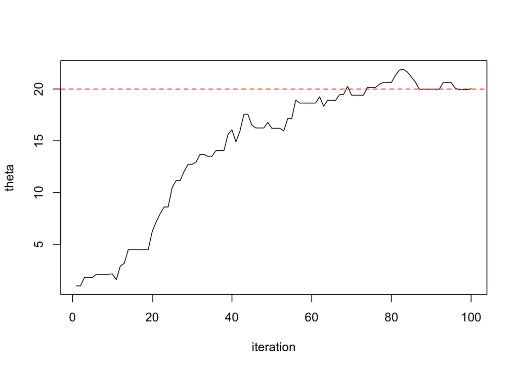

```r
set.seed(12345)
y <- rnorm(25, 20, 5)

mm <- metrop(y)

## Plotting the trace for theta
plot(mm$theta, xlab = "iteration", ylab = "theta", type = "l")
abline(h = mean(y), col = "red", lty = 2)
```

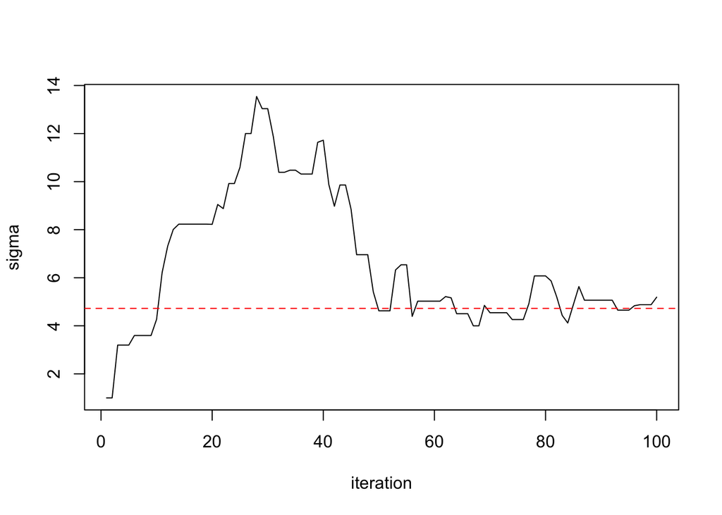

```r
## Trace plot for sigma
plot(mm$sigma, xlab = "iteration", ylab = "sigma", type = "l")
abline(h = sd(y), col = "red", lty = 2)
```

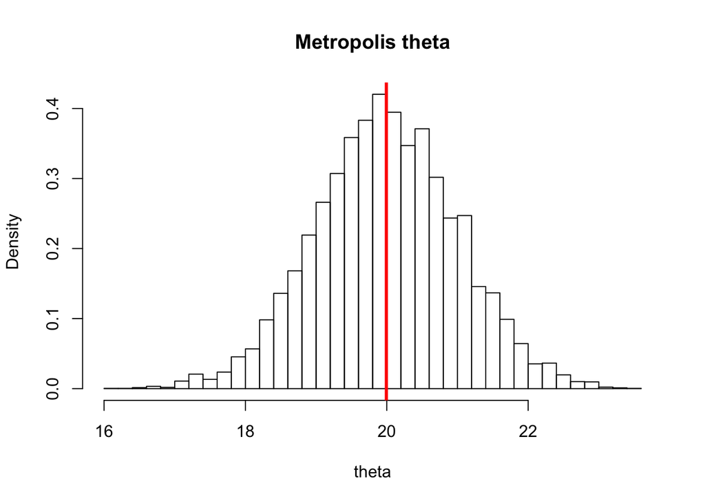

```r
## More samples
mm2 <- metrop(y, n = 15e3)

## Distribution
hist(mm2$theta[1e3:15e3], xlab = "theta", main = "Metropolis theta",
     freq = FALSE, breaks = 30)
abline(v = mean(y), col = "red", lwd = 3)
```

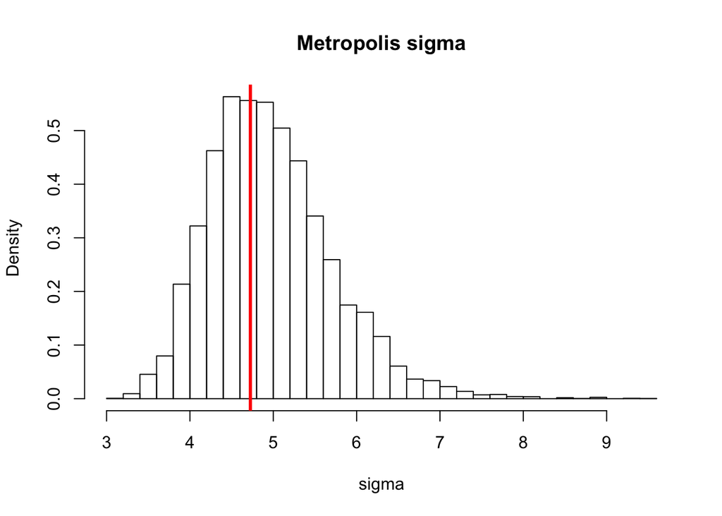

```r
hist(mm2$sigma[1e3:15e3], xlab = "sigma", main = "Metropolis sigma",
     freq = FALSE, breaks = 30)
abline(v = sd(y), col = "red", lwd = 3)
```